# Lab08

Channing_503128649

03/10/2021

# Setup

```r
library(MASS)
library(class)
library(gam)
library(nnet)
library(e1071)
library(parallel)
```

# Import

```r
vc = read.csv("vertebral-column.csv", stringsAsFactors=TRUE)
head(vc)
```

```
##      pi    pt   lla    ss     pr   gos class
## 1 63.03 22.55 39.61 40.48  98.67 -0.25    DH
## 2 39.06 10.06 25.02 29.00 114.41  4.56    DH
## 3 68.83 22.22 50.09 46.61 105.99 -3.53    DH
## 4 69.30 24.65 44.31 44.64 101.87 11.21    DH
## 5 49.71  9.65 28.32 40.06 108.17  7.92    DH
## 6 40.25 13.92 25.12 26.33 130.33  2.23    DH
```

# Exploration

1. Create a pairwise scatterplot, with observations of different classes shown in different colors.

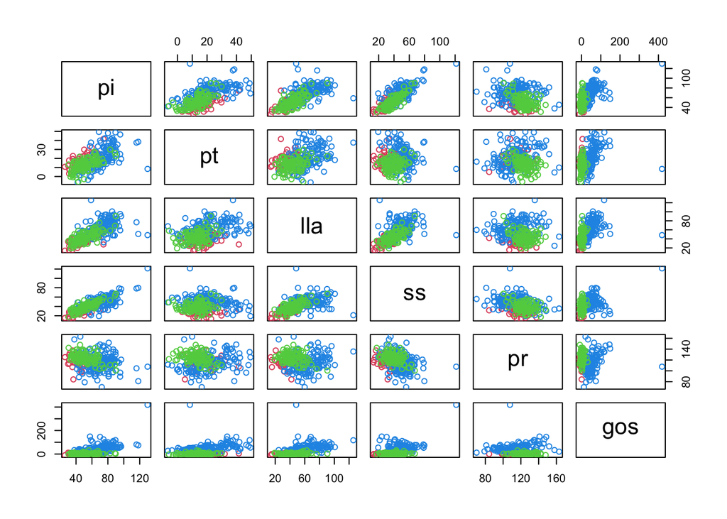

```r
plot(vc[,-7], col=as.numeric(vc[,7])+1)
```

# Classification Five classification methods are listed in the next 5 tasks. Use each of them to build a model for the data set vc and predict the class labels of the observations that are used to build the model. For each, compute the confusion matrix and (resubstitution) classification accuracy.

```r
r = vector("list", 5)
A = vector("numeric", 5)
names(r) = c("LDA", "QDA", "NB", "MLR", "KNN")
names(A) = c("LDA", "QDA", "NB", "MLR", "KNN")
```

2. Linear discriminant analysis

```r
r[[1]] = lda(class ~ ., data=vc)
yhat = predict(r[[1]], newdata=vc)$class
table(vc$class, yhat)
```

```
##     yhat
##       DH  NO  SL
##   DH  39  20   1
##   NO  12  79   9
##   SL   4  11 135
```

```r
(A[1] = mean(vc$class == yhat))
```

```
## [1] 0.816129
```

3. Quadratic discriminant analysis

```r
r[[2]] = qda(class ~ ., data=vc)
yhat = predict(r[[2]], newdata=vc)$class
table(vc$class, yhat)
```

```
##     yhat
##       DH  NO  SL
##   DH  42  16   2
##   NO  15  81   4
##   SL   1   1 148
```

```r
(A[2] = mean(vc$class == yhat))
```

```
## [1] 0.8741935
```

4. Naive Bayes

```r
r[[3]] = naiveBayes(class ~ ., data=vc)
yhat = predict(r[[3]], newdata=vc)
table(vc$class, yhat)
```

```
##     yhat
##       DH  NO  SL
##   DH  45  12   3
##   NO  21  69  10
##   SL   0   5 145
```

```r
(A[3] = mean(vc$class == yhat))
```

```
## [1] 0.8354839
```

5. Multinomial logistic regression

```r
r[[4]] = multinom(class ~ ., data=vc)
yhat = predict(r[[4]], newdata=vc)
table(vc$class, yhat)
```

```
##     yhat
##       DH  NO  SL
##   DH  40  19   1
##   NO  13  85   2
##   SL   1   3 146
```

```r
(A[4] = mean(vc$class == yhat))
```

```
## [1] 0.8741935
```

6. K-nearest neighbours (with K=10)

```r
yhat = knn(train=vc[,-7], test=vc[,-7], cl=vc[,7], k=10)  # K = 1
table(vc[,7], yhat)
```

```
##     yhat
##       DH  NO  SL
##   DH  43  16   1
##   NO  13  84   3
##   SL   1   3 146
```

```r
(A[5] = mean(vc$class == yhat))
```

```
## [1] 0.8806452
```

# Primary Performance Evaluation

7. Present your resulting classification accuracy for all five classification methods in a table (in whatever format)

```r
names(A[which.max(A)])
```

```
## [1] "KNN"
```

```r
length(unique(vc$class))
```

```
## [1] 3
```

All of them do a better job (Accuracy >80%) than the random guess (Accuracy = 33.33%), where KNN performed the best.

# Multiple Logistic Regression and Generalised Additive Models

8. Create a response variable from variable class so that both classes DH and SL are relabelled as AB (Abnormal).

```r
vc$newclass = as.factor(ifelse(vc$class=="DH" | vc[, 7]=="SL","AB", "NO"))
```

Use glm() to build a multiple logistic regression model for this new class variable, and compute the confusion matrix and resubstitution classification accuracy.

```r
r1 = glm(newclass ~ .-class, data=vc, family=binomial)
p = predict(r1, newdata=vc, type="response")
yhat = as.numeric(p > 0.5) + 1
table(vc$newclass, levels(vc$newclass)[yhat])
```

```
##
##       AB  NO
##   AB 188  22
##   NO  22  78
```

```r
(A1 = mean(vc$newclass == levels(vc$newclass)[yhat]))
```

```
## [1] 0.8580645
```

(@)Use step() to find the AIC-selected model, with backward selection. Which variables are removed by the AIC?

```r
r1 = step(r1, type="backward")
```

```
## Start:  AIC=192.13
## newclass ~ (pi + pt + lla + ss + pr + gos + class) - class
```

```
##        Df Deviance    AIC
## - ss    1   178.27 190.27
## - pi    1   178.27 190.27
## - pt    1   178.27 190.27
## - lla   1   178.86 190.86
## <none>      178.13 192.13
## - pr    1   209.31 221.31
## - gos   1   302.31 314.31
```

```
##
## Step:  AIC=190.27
## newclass ~ pi + pt + lla + pr + gos
```

```
##        Df Deviance    AIC
## - lla   1   178.95 188.95
## <none>      178.27 190.27
## - pi    1   189.08 199.08
## - pt    1   202.23 212.23
## - pr    1   209.36 219.36
## - gos   1   303.45 313.45
```

```
##
## Step:  AIC=188.95
## newclass ~ pi + pt + pr + gos
```

```
##        Df Deviance    AIC
## <none>      178.95 188.95
## - pt    1   208.55 216.55
## - pr    1   212.18 220.18
## - pi    1   212.53 220.53
## - gos   1   310.54 318.53
```

```r
summary(r1)
```

```
##
## Call:
## glm(formula = newclass ~ pi + pt + pr + gos, family = binomial,
##     data = vc)
##
## Deviance Residuals:
##      Min        1Q    Median        3Q       Max
## -2.21933  -0.37927  -0.03193   0.40184   2.79266
##
## Coefficients:
##              Estimate Std. Error z value Pr(>|z|)
## (Intercept) -15.45723    3.27273  -4.723 2.32e-06 ***
## pi            0.11495    0.02266   5.072 3.94e-07 ***
## pt           -0.18140    0.03784  -4.794 1.63e-06 ***
## pr            0.10895    0.02279   4.780 1.75e-06 ***
## gos          -0.16538    0.02288  -7.227 4.92e-13 ***
## ---
## Signif. codes:  0 '***' 0.001 '**' 0.01 '*' 0.05 '.' 0.1 ' ' 1
##
## (Dispersion parameter for binomial family taken to be 1)
##
##     Null deviance: 389.86  on 309  degrees of freedom
## Residual deviance: 178.95  on 305  degrees of freedom
## AIC: 188.95
##
## Number of Fisher Scoring iterations: 8
```

llr, ss are removed by AIC

9. Extend the AIC-selected model with gam() so that each linear term is replaced with a smoothing spline of 5 degrees of freedom. Take a visual approach to reasonably lower the degrees of freedom in each term. For your chosen model, compute the confusion matrix and classification accuracy.

```r
par(mfrow=c(2,3))
r1 = gam(newclass ~ s(pi, 5) + s(lla, 5) + s(ss, 5) + s(pr,5) + s(gos, 5), data=vc, family=binomial())
summary(r1)
```

```
##
## Call: gam(formula = newclass ~ s(pi, 5) + s(lla, 5) + s(ss, 5) + s(pr,
##     5) + s(gos, 5), family = binomial(), data = vc)
## Deviance Residuals:
##       Min        1Q    Median        3Q       Max
## -2.054408 -0.248374 -0.004163  0.312835  2.596147
##
## (Dispersion Parameter for binomial family taken to be 1)
##
##     Null Deviance: 389.8556 on 309 degrees of freedom
## Residual Deviance: 143.8526 on 284 degrees of freedom
## AIC: 195.8526
##
## Number of Local Scoring Iterations: NA
##
## Anova for Parametric Effects
##            Df  Sum Sq Mean Sq F value    Pr(>F)
## s(pi, 5)    1   0.020   0.020  0.0375 0.8466535
## s(lla, 5)   1   1.041   1.041  1.9317 0.1656579
## s(ss, 5)    1   7.138   7.138 13.2452 0.0003246 ***
## s(pr, 5)    1  10.002  10.002 18.5593 2.272e-05 ***
## s(gos, 5)   1  39.617  39.617 73.5117 6.557e-16 ***
## Residuals 284 153.054   0.539
## ---
## Signif. codes:  0 '***' 0.001 '**' 0.01 '*' 0.05 '.' 0.1 ' ' 1
##
## Anova for Nonparametric Effects
##             Npar Df Npar Chisq  P(Chi)
## (Intercept)
## s(pi, 5)          4     8.4470 0.07650 .
## s(lla, 5)         4     5.4449 0.24463
## s(ss, 5)          4     2.8070 0.59055
## s(pr, 5)          4     4.5488 0.33683
## s(gos, 5)         4    11.4353 0.02209 *
## ---
## Signif. codes:  0 '***' 0.001 '**' 0.01 '*' 0.05 '.' 0.1 ' ' 1
```

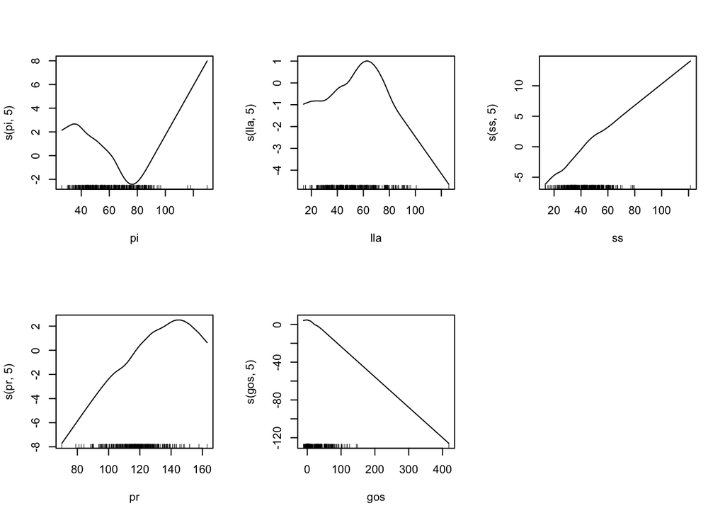

```r
plot(r1)
```

pi, lla, pr seem to be quadratic regressions and ss, gos seem to linear regression

```r
r1 = gam(newclass ~ s(pi, 2) + s(lla, 2) + ss + s(pr,2) + gos, data=vc, family=binomial())
p = predict(r1, vc)
yhat = as.numeric(p > 0.5) + 1
table(vc$newclass, levels(vc$newclass)[yhat])
```

```
##
##       AB  NO
##   AB 199  11
##   NO  28  72
```

```r
(A1 = mean(vc$newclass == levels(vc$newclass)[yhat]))
```

```
## [1] 0.8741935
```

# Cross-validation and Parallel Computing

10. Reconsider the 3-class problem studied in Questions 2-7. Use 10 repetitions of 10-fold cross-validation to evaluate the performance of the 5 classification methods. Present your resulting classification accuracy of all five classification methods in a table. Comment on the results.

```r
vc = read.csv("vertebral-column.csv", stringsAsFactors=TRUE)

n = nrow(vc)       # total number of observations
c = 1:5  # all the classifiers for comparison
R = 5                   # number of repetitions
K = 10                  # K-fold CV
a = matrix(nrow=R*K, ncol=length(c))   # pre-allocate space

# indies of a test test in CV
# i -- which fold
# n -- sample size
# K -- total number of folds

test.set = function(i, n, K=10) {
  if(i < 1 || i > K)
    stop(" i out of range (1, K)")
  start = round(1 + (i-1) * n / K)
  end = ifelse(i == K, n, round(i * n / K))
  start:end
}

set.seed(769)           # set a random seed

for(i in 1:R) {                  # for each repetition
  ind = sample(n)
  for(k in 1:K) {                # for each fold
    index = ind[test.set(k, n, K)]
    test = vc[index,]
    train = vc[-index,]
    for(j in 1:length(c)) {     # for each classifier
      if (j ==1 || j ==2) yhat = predict(r[[1]], newdata=test)$class
      if (j ==3 || j ==4) yhat = predict(r[[j]], newdata=test)
      if (j == 5) yhat = knn(train=train[,-7], test=test[,-7], cl=train[,7], k=10)
      a[K*(i-1)+k,j] = mean(test$class == yhat)
    }
  }
}

head(a)
```

```
##           [,1]      [,2]      [,3]      [,4]      [,5]
## [1,] 0.8387097 0.8387097 0.7741935 0.8709677 0.8064516
## [2,] 0.8709677 0.8709677 0.8387097 0.9677419 0.9032258
## [3,] 0.6451613 0.6451613 0.7096774 0.7419355 0.7741935
## [4,] 0.7741935 0.7741935 0.8064516 0.8387097 0.8064516
## [5,] 0.7741935 0.7741935 0.7741935 0.8064516 0.8064516
## [6,] 0.7741935 0.7741935 0.8387097 0.8064516 0.7741935
```

```r
(pe = cbind(c=c, a=colMeans(a)))
```

```
##      c         a
## [1,] 1 0.8161290
## [2,] 2 0.8161290
## [3,] 3 0.8354839
## [4,] 4 0.8741935
## [5,] 5 0.8283871
```

# Summary

In this lab, we look into the classification problems.

Secondly, we transformed the reponse variables into 2 classes (‘NO’ and ‘AB’) rather than 3 classes (‘NO’, ‘DH’, ‘SL’) and then compared between Multiple Logistic Regression and Generalised Additive Models. We can see that GAM performed slightly better, but it needs an extra step to tune the pynonomial degrees in each smoothing splines.